# Atividade 2 - PCA

Análise Multivariada - 2026.1

Autor

Milena Paz Freitas

# Questão 1

Faremos uma análise fatorial por método de componentes principais, já que não sabemos a distribuição dos dados. Assim, procedemos:

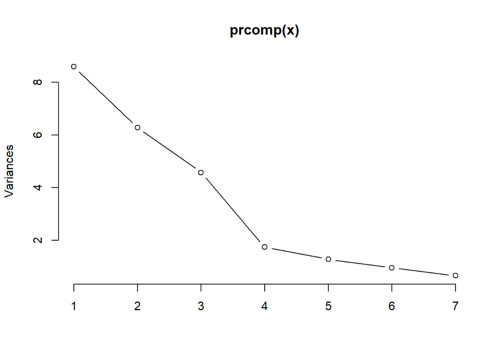

```r
x=read.csv2("home.csv",row.names = 1)
R=cor(x)
E <- eigen(R)$vectors
lambda <- eigen(R)$values
L <- E%*%diag(sqrt(lambda))
#numero de componentes
screeplot(prcomp(x),type='l')
```

```r
#faremos com 4 fatores, que é onde está o "cotovelo" do screeplot.
L4 <- L[,1:4]
comum <- rowSums(L4**2)
R4 <- tcrossprod(L)

#verificando residuos
all(R-R4<0.05)
```

```
[1] TRUE
```

```r
#parece ser ok, usaremos essa iteração

round(L4,3)
```

```
       [,1]   [,2]   [,3]   [,4]
[1,]  0.817  0.378 -0.087 -0.013
[2,]  0.279 -0.714 -0.457 -0.361
[3,]  0.887 -0.027  0.043  0.277
[4,] -0.204  0.634 -0.597  0.268
[5,]  0.664  0.505 -0.329 -0.330
[6,]  0.050 -0.604 -0.689  0.296
[7,] -0.684  0.383 -0.426 -0.181
```

Olhando pela matriz de loadings, temos que o primeiro fator representa as perguntas que mais identificam uma pessoa “caseira”, enquanto o segundo fator contrasta compradores analíticos vs. aqueles que evitam os que têm propaganda. O terceiro e quarto fatores são de difícil interpretação. Aplicando uma rotação ortogonal na matriz de loadings, obtemos:

```r
rot <- varimax(L4)$loadings
print(rot,cutoff=0.25)
```

```
Loadings:
     [,1]   [,2]   [,3]   [,4]
[1,]  0.748                0.495
[2,]        -0.391 -0.863
[3,]  0.418                0.823
[4,]         0.882
[5,]  0.940
[6,]               -0.904
[7,]         0.486        -0.767

                [,1]  [,2]  [,3]  [,4]
SS loadings    1.731 1.249 1.583 1.591
Proportion Var 0.247 0.178 0.226 0.227
Cumulative Var 0.247 0.426 0.652 0.879
```

Feita a rotação, temos que o primeiro fator continua com a mesma interpretabilidade (fator ‘caseiro’); o segundo é relacionado ao desgosto por propagandas(fator ‘cínico’); o terceiro caracteriza um comprador atencioso aos preços e descontos (fator ‘pechincha’); o quarto é de difícil interpretação, contrasta pessoas ‘caseiras’ vs. acreditar que propagandas são desperdício de dinheiro.

Evidentemente, a rotação auxiliou com a interpretabilidade dos fatores e é preferível. Verificamos a matriz residual relativa ao modelo anterior e posterior à rotação:

```r
R-R4
```

```
              Q1            Q2            Q3            Q4            Q5
Q1 -4.440892e-16  2.112026e-16  3.330669e-16 -2.775558e-16  3.330669e-16
Q2  2.112026e-16 -4.440892e-16 -6.383782e-16  7.216450e-16  4.718448e-16
Q3  3.330669e-16 -6.383782e-16  3.330669e-16  0.000000e+00  8.326673e-16
Q4 -2.775558e-16  7.216450e-16  0.000000e+00  2.220446e-16 -5.551115e-16
Q5  3.330669e-16  4.718448e-16  8.326673e-16 -5.551115e-16  3.330669e-16
Q6  2.081668e-16 -4.440892e-16 -3.747003e-16  2.463307e-16  8.326673e-17
Q7 -1.665335e-16 -5.551115e-17 -3.330669e-16 -3.330669e-16 -8.881784e-16
              Q6            Q7
Q1  2.081668e-16 -1.665335e-16
Q2 -4.440892e-16 -5.551115e-17
Q3 -3.747003e-16 -3.330669e-16
Q4  2.463307e-16 -3.330669e-16
Q5  8.326673e-17 -8.881784e-16
Q6 -2.220446e-16 -2.498002e-16
Q7 -2.498002e-16  0.000000e+00
```

```r
R-tcrossprod(rot)
```

```
             Q1           Q2           Q3          Q4          Q5          Q6
Q1  0.181955516 -0.006125473 -0.079185126 -0.03910925 -0.09147252  0.03075427
Q2 -0.006125473  0.073587451  0.003993703  0.08460481 -0.04576823 -0.07030726
Q3 -0.079185126  0.003993703  0.133603111 -0.03206345  0.01067742 -0.02247811
Q4 -0.039109253  0.084604813 -0.032063453  0.12876051 -0.02136426 -0.08123252
Q5 -0.091472522 -0.045768228  0.010677415 -0.02136426  0.08655093  0.03288580
Q6  0.030754275 -0.070307262 -0.022478112 -0.08123252  0.03288580  0.07121107
Q7  0.037207296 -0.046925415  0.098563816 -0.11883024 -0.02124017  0.04026106
            Q7
Q1  0.03720730
Q2 -0.04692542
Q3  0.09856382
Q4 -0.11883024
Q5 -0.02124017
Q6  0.04026106
Q7  0.17081670
```

Calcularemos as comunalidades para as duas matrizes de loadings obtidas:

```r
rowSums(L4^2)
```

```
[1] 0.8180445 0.9264125 0.8663969 0.8712395 0.9134491 0.9287889 0.8291833
```

```r
rowSums(rot^2)
```

```
[1] 0.8180445 0.9264125 0.8663969 0.8712395 0.9134491 0.9287889 0.8291833
```

Agora as variâncias específicas:

```r
1-rowSums(L4^2)
```

```
[1] 0.18195552 0.07358745 0.13360311 0.12876051 0.08655093 0.07121107 0.17081670
```

```r
1-rowSums(rot^2)
```

```
[1] 0.18195552 0.07358745 0.13360311 0.12876051 0.08655093 0.07121107 0.17081670
```

Tanto as comunalidades quanto as especificidades são as mesmas para antes e depois da rotação. Vamos observar os escores da amostra:

```r
z <- scale(x)
f=z%*%solve(R)%*%rot
head(round(f,3))
```

```
    [,1]   [,2]   [,3]   [,4]
1  0.491  1.506  0.855  1.150
2  1.110  0.595 -1.559 -0.096
3  0.709  1.251 -0.428 -0.484
4 -1.666  0.421  1.054  0.629
5 -0.696 -1.180  1.744  0.089
6 -0.667  0.050 -1.518 -0.913
```

Temos que os escores indicam, por exemplo, que o primeiro elemento é cínico de propagandas e gosta de pechinchar; o perfil do segundo é de uma pessoa caseira que não é nada atenta aos preços e descontos.

Agora faremos uma rotação não-ortogonal nos dados, ou seja, haverá correlação entre os fatores se fizermos:

```r
obliq <- GPArotation::oblimin(L4)
print(obliq$loadings,digits=2)
```

```
       [,1]    [,2]   [,3]   [,4]
[1,]  0.461  0.0895 -0.110 -0.652
[2,] -0.113 -0.8422  0.404 -0.235
[3,]  0.827 -0.0825 -0.055 -0.255
[4,] -0.215 -0.0183 -0.840 -0.208
[5,]  0.027  0.0049 -0.083 -0.936
[6,]  0.137 -0.9202 -0.287  0.213
[7,] -0.787  0.0015 -0.360 -0.087
```

Faremos uma análise de escores para essa matriz:

```r
head(round(z%*%solve(R)%*%rot%*%obliq$Phi,2))
```

```
   [,1]  [,2]  [,3]  [,4]
1  0.24  1.38  0.94  1.08
2  0.82  0.66 -1.42 -0.58
3  0.68  1.25 -0.46 -0.75
4 -1.67  0.42  0.79  1.19
5 -0.33 -1.29  1.73  0.50
6 -0.70  0.24 -1.74 -0.90
```

Para os mesmos indivíduos que antes: o primeiro gosta de pechinchar e é caseiro, enquanto o segundo gosta de internet e é um comprador que não gosta de propagandas. Ou seja, após aplicar uma rotação oblíqua, não só mudaram as interpretações dos fatores, mas também houve uma mudança nos perfis dos compradores.

# Questão 2

Vamos reconstruir a matriz P por meio do modelo fatorial sugerido pelo enunciado:

```r
P=diag(nrow=3,ncol=3)
P[lower.tri(P)] <- c(0.63,0.45,0.35) -> P[upper.tri(P)]
P
```

```
     [,1] [,2] [,3]
[1,] 1.00 0.63 0.45
[2,] 0.63 1.00 0.35
[3,] 0.45 0.35 1.00
```

```r
#um fator
L <- matrix(c(0.9,0.7,0.5),ncol=1)
Psi<-diag(c(0.19,0.51,0.75))
#RECONSTRUINDO P
tcrossprod(L)+Psi
```

```
     [,1] [,2] [,3]
[1,] 1.00 0.63 0.45
[2,] 0.63 1.00 0.35
[3,] 0.45 0.35 1.00
```

Calcularemos as comunalidades do primeiro fator:

```r
#Comunalidades de F1
L**2
```

```
     [,1]
[1,] 0.81
[2,] 0.49
[3,] 0.25
```

Temos que maior parte da variância de $Z_1$ é explicada pelo fator, 81%, enquanto $Z_2$ e $Z_3$ são explicados em 49% e 25%, respectivamente. A primeira variável é, então a mais representada. Como o modelo é ortogonal, as correlações $Cor(F_1,\bm X)$ são a matriz de loadings:

```r
# Correlações entre fator e variáveis originais
L
```

```
     [,1]
[1,]  0.9
[2,]  0.7
[3,]  0.5
```

Evidentemente, o primeiro fator tem maior peso na variável $X_1$, pois possui a maior correlação com ela. Encontraremos os autovalores e autovetores de P para realizar uma análise fatorial via componentes principais:

```r
lambda <- eigen(P)$values
E <- eigen(P)$vectors

L1 <- (E%*%diag(sqrt(lambda)))[,1]
L1
```

```
[1] -0.8757363 -0.8311066 -0.7110772
```

```r
Psi <- diag(1-L1**2)
Psi
```

```
         [,1]      [,2]      [,3]
[1,] 0.233086 0.0000000 0.0000000
[2,] 0.000000 0.3092618 0.0000000
[3,] 0.000000 0.0000000 0.4943692
```

```r
#reconstruindo P:
(tcrossprod(L1)+Psi)
```

```
          [,1]      [,2]      [,3]
[1,] 1.0000000 0.7278302 0.6227161
[2,] 0.7278302 1.0000000 0.5909810
[3,] 0.6227161 0.5909810 1.0000000
```

```r
# a reconstrução não é muito boa, vamos fazer iterativamente:
comum=L1**2
delta=100
while(delta>1E-5){
  R <- P
  diag(R) <- L1**2
  #usando svd no lugar de eigen por estabilidade numerica
  #(ausencia de autovalores proximos de 0 negativos)
  lambda <- svd(R)$d
  E <- svd(R)$u
  L <- E%*%diag(sqrt(lambda))
  L1 <- L[,1]
  Psi <- diag(1-L1**2)
  delta= sum((comum-L1**2)^2)
  R.st=tcrossprod(L1)+Psi
  comum=L1**2
}
#loadings
L1
```

```
[1] -0.8914259 -0.7054757 -0.5015566
```

```r
#variancia especifica
Psi
```

```
          [,1]      [,2]     [,3]
[1,] 0.2053598 0.0000000 0.000000
[2,] 0.0000000 0.5023041 0.000000
[3,] 0.0000000 0.0000000 0.748441
```

```r
#reconstrucao final
R.st
```

```
          [,1]      [,2]      [,3]
[1,] 1.0000000 0.6288793 0.4471006
[2,] 0.6288793 1.0000000 0.3538360
[3,] 0.4471006 0.3538360 1.0000000
```

```r
#comunalidades
comum
```

```
[1] 0.7946402 0.4976959 0.2515590
```

Temos que, ao fim dessa aproximação temos resultados muito próximos aos usados no começo do exercício. A proporção da variância explicada pelo fator 1 é:

```r
lambda[1]/sum(lambda)
```

```
[1] 0.9931673
```

Ou seja, quase toda a variância total (99.3%) é explicada pelo primeiro fator.

# Questão 3

A partir da equação $\Sigma=LL'+\Psi$ e para p=2 e m=1 temos:

$$\mat{\sigma_{11}&\sigma_{12}\\\sigma_{21}&\sigma_{22}}=\mat{l^2_{11}+\psi_1&l_{21}l_{11}\\l_{21}l_{11}&l^2_{21}+\psi_2}$$

Logo: $\sigma_{11}=l^2_{11}+\psi_1$, $\sigma_{12}=\sigma_{21}=l_{21}l_{11}$ e $\sigma_{22}=l^2_{21}+\psi_2$.

A partir dessa equação matricial, temos um sistema:

$$\begin{cases}
l^2_{11}+\psi_1-\sigma_{11}=0\\
l^2_{21}+\psi_2-\sigma_{22}=0\\
l_{21}l_{11} -\sigma_{12} =0
\end{cases}$$

As incógnitas, no caso, seriam os l’s e os psi’s. Porém, temos quatro valores desconhecidos para 3 equações. Dessa forma, o sistema é considerado subdeterminado, o que implica uma infinidade de soluções.

# Questão 4

Para essa matriz temos que as equações como definidas pela equação $\Sigma=LL'+\Psi$ são:

$$\begin{cases}
l^2_{11}+\psi_1=1\\
l^2_{21}+\psi_2=1\\
l^2_{31}+\psi_3=1\\
l_{21}l_{11} = 0.4\\
l_{31}l_{11} = 0.9\\
l_{31}l_{21} = 0.7
\end{cases}$$

Logo, temos que: $l_{21}/l_{31}=4/9$ e $l_{31}l_{21}=0.7$ então: $l_{21}^2=0.7×4/9=0.3111...\Rightarrow l_{21}=\pm0.558$. Equivalentemente: $l_{11}=\pm0.717$ e $l_{31}=\pm1.255$. Já temos algo estranho por este valor de $l_{31}$ ser maior que 1. A partir de $LL'$, temos que seu elemento da linha 3 e coluna 3 é $l_{31}^2=1.575$; voltando ao sistema: $\psi_3=1-1.575=-0.575<0$. Como os psi’s são variâncias (específicas), a solução não é própria pois variâncias não assumem valores negativos.

# Questão 5

Primeiramente, padronizaremos as variáveis para realizar uma análise fatorial ortogonal:

```r
x=read.table("T9-12.dat",
             col.names = c("Crescimento","Lucratividade","Novas",
                           "tCriatividade","tMecanico","tAbstrato","tMatematico"))
z <- scale(x)
z[,1:3] <- apply(x[,1:3],2, function(x) (x-100)/sd(x))
```

Faremos uma estimação por meio de componentes principais, como segue:

```r
P <- cov(z)
lambda <- svd(P)$d
E <- svd(P)$u

round(L2 <- (E%*%diag(sqrt(lambda)))[,1:2],3)
```

```
       [,1]   [,2]
[1,] -0.973  0.108
[2,] -0.943 -0.028
[3,] -0.945 -0.009
[4,] -0.660 -0.646
[5,] -0.783 -0.285
[6,] -0.649  0.621
[7,] -0.914  0.194
```

```r
round(L3 <- (E%*%diag(sqrt(lambda)))[,1:3],3)
```

```
       [,1]   [,2]   [,3]
[1,] -0.973  0.108  0.053
[2,] -0.943 -0.028  0.312
[3,] -0.945 -0.009 -0.144
[4,] -0.660 -0.646 -0.319
[5,] -0.783 -0.285 -0.004
[6,] -0.649  0.621 -0.426
[7,] -0.914  0.194  0.306
```

```r
round(Psi2 <- diag(1-rowSums(L2**2)),3)
```

```
      [,1] [,2]  [,3]  [,4]  [,5]  [,6]  [,7]
[1,] 0.041 0.00 0.000 0.000 0.000 0.000 0.000
[2,] 0.000 0.11 0.000 0.000 0.000 0.000 0.000
[3,] 0.000 0.00 0.107 0.000 0.000 0.000 0.000
[4,] 0.000 0.00 0.000 0.147 0.000 0.000 0.000
[5,] 0.000 0.00 0.000 0.000 0.305 0.000 0.000
[6,] 0.000 0.00 0.000 0.000 0.000 0.194 0.000
[7,] 0.000 0.00 0.000 0.000 0.000 0.000 0.127
```

```r
round(Psi3 <- diag(1-rowSums(L3**2)),3)
```

```
      [,1]  [,2]  [,3]  [,4]  [,5]  [,6]  [,7]
[1,] 0.039 0.000 0.000 0.000 0.000 0.000 0.000
[2,] 0.000 0.013 0.000 0.000 0.000 0.000 0.000
[3,] 0.000 0.000 0.087 0.000 0.000 0.000 0.000
[4,] 0.000 0.000 0.000 0.045 0.000 0.000 0.000
[5,] 0.000 0.000 0.000 0.000 0.305 0.000 0.000
[6,] 0.000 0.000 0.000 0.000 0.000 0.012 0.000
[7,] 0.000 0.000 0.000 0.000 0.000 0.000 0.033
```

Com esses resultados (ambos válidos), temos as seguintes rotações:

```r
L2r <- varimax(L2)$loadings; L3r <- varimax(L3)$loadings
print(L2r,cutoff=0.25);print(L3r,cutoff=0.25)
```

```
Loadings:
     [,1]   [,2]
[1,] -0.785 -0.585
[2,] -0.670 -0.664
[3,] -0.685 -0.651
[4,]        -0.923
[5,] -0.379 -0.743
[6,] -0.898
[7,] -0.801 -0.482

                [,1]  [,2]
SS loadings    3.128 2.840
Proportion Var 0.447 0.406
Cumulative Var 0.447 0.853
```

```
Loadings:
     [,1]   [,2]   [,3]
[1,] -0.779 -0.387 -0.452
[2,] -0.908 -0.356
[3,] -0.616 -0.548 -0.483
[4,]        -0.952
[5,] -0.552 -0.607
[6,] -0.287        -0.950
[7,] -0.909        -0.328

                [,1]  [,2]  [,3]
SS loadings    3.071 1.889 1.506
Proportion Var 0.439 0.270 0.215
Cumulative Var 0.439 0.709 0.924
```

Abaixo estão as comunalidades, variâncias específicas e $LL'+\Psi$ para cada modelo.

```r
round(cbind(comunalidade=rowSums(L2r**2),
            especificidade=1-rowSums(L2r**2)),3)
```

```
     comunalidade especificidade
[1,]        0.959          0.041
[2,]        0.890          0.110
[3,]        0.893          0.107
[4,]        0.853          0.147
[5,]        0.695          0.305
[6,]        0.806          0.194
[7,]        0.873          0.127
```

```r
round(R2 <- tcrossprod(L2)+Psi2,2)
```

```
     [,1] [,2] [,3] [,4] [,5] [,6] [,7]
[1,] 1.00 0.91 0.92 0.57 0.73 0.70 0.91
[2,] 0.91 1.00 0.89 0.64 0.75 0.59 0.86
[3,] 0.92 0.89 1.00 0.63 0.74 0.61 0.86
[4,] 0.57 0.64 0.63 1.00 0.70 0.03 0.48
[5,] 0.73 0.75 0.74 0.70 1.00 0.33 0.66
[6,] 0.70 0.59 0.61 0.03 0.33 1.00 0.71
[7,] 0.91 0.86 0.86 0.48 0.66 0.71 1.00
```

```r
round(cbind(comunalidade=rowSums(L3r**2),
            especificidade=1-rowSums(L3r**2)),3)
```

```
     comunalidade especificidade
[1,]        0.961          0.039
[2,]        0.987          0.013
[3,]        0.913          0.087
[4,]        0.955          0.045
[5,]        0.695          0.305
[6,]        0.988          0.012
[7,]        0.967          0.033
```

```r
round(R3 <- tcrossprod(L3r)+Psi3,2)
```

```
     [,1] [,2] [,3] [,4] [,5] [,6] [,7]
[1,] 1.00 0.93 0.91 0.56 0.73 0.68 0.93
[2,] 0.93 1.00 0.85 0.54 0.75 0.46 0.95
[3,] 0.91 0.85 1.00 0.68 0.74 0.67 0.82
[4,] 0.56 0.54 0.68 1.00 0.70 0.16 0.38
[5,] 0.73 0.75 0.74 0.70 1.00 0.33 0.66
[6,] 0.68 0.46 0.67 0.16 0.33 1.00 0.58
[7,] 0.93 0.95 0.82 0.38 0.66 0.58 1.00
```

```r
#matriz de correlacoes, de referencia
round(P,2)
```

```
              Crescimento Lucratividade Novas tCriatividade tMecanico tAbstrato
Crescimento          1.00          0.93  0.88          0.57      0.71      0.67
Lucratividade        0.93          1.00  0.84          0.54      0.75      0.47
Novas                0.88          0.84  1.00          0.70      0.64      0.64
tCriatividade        0.57          0.54  0.70          1.00      0.59      0.15
tMecanico            0.71          0.75  0.64          0.59      1.00      0.39
tAbstrato            0.67          0.47  0.64          0.15      0.39      1.00
tMatematico          0.93          0.94  0.85          0.41      0.57      0.57
              tMatematico
Crescimento          0.93
Lucratividade        0.94
Novas                0.85
tCriatividade        0.41
tMecanico            0.57
tAbstrato            0.57
tMatematico          1.00
```

Por produzir melhor aproximação de $P$ e melhor interpretatividade, o modelo com m=3 aparenta ser mais adequado. Faremos um teste ao nivel de 1% para verificar se os modelos acima são adequados:

```r
n=nrow(x)
teste <- function(R,m){
  p=ncol(R)
  t <- (n-1-(2*p+4*m+5)/6)*log(det(R)/det(P))
  gl=((p-m)^2-p-m)/2
  cat("m =",m,"Fatores\n","p-valor:",1-pchisq(t,gl),"\n")
}
teste(R2,2)
```

```
m = 2 Fatores
 p-valor: 0
```

```r
teste(R3,3)
```

```
m = 3 Fatores
 p-valor: 2.244744e-06
```

Como ambos testes, podemos observar que nenhum dos dois é adequado. Porém, seguindo o julgamento anterior, o modelo m=3 é preferível.

Supondo que haja um novo vendedor com a seguinte observação:

```r
xi <- c(110,98,105,15,18,12,35)
#padronizado
zi <- (xi-c(rep(100,3),attributes(z)$`scaled:center`[4:7]))/attributes(z)$`scaled:scale`
```

Calcularemos o score desse vendedor como segue:

```r
freg <-t(L3r)%*%solve(R3)%*%zi
fmqp <- solve(t(L3r)%*%solve(Psi3)%*%L3)%*%(t(L3r)%*%solve(Psi3)%*%zi)
cat("Escores por método de Regressão:\n",freg,"\n")
```

```
Escores por método de Regressão:
 0.3963015 -1.091631 -0.8777817
```

```r
cat("Escores por método de Mínimos Quadrados Ponderados:\n",fmqp)
```

```
Escores por método de Mínimos Quadrados Ponderados:
 -0.6365073 -0.3104118 -1.358163
```

# Questão 6

Usando esta matriz de correlações e desvios-padrão:

```r
R=diag(nrow=4)
R[lower.tri(R)] <- c(.7501,.6329,.6363,.6925,.7386,.6625) -> R[upper.tri(R)]
R
```

```
       [,1]   [,2]   [,3]   [,4]
[1,] 1.0000 0.7501 0.6329 0.6925
[2,] 0.7501 1.0000 0.6363 0.7386
[3,] 0.6329 0.6925 1.0000 0.6625
[4,] 0.6363 0.7386 0.6625 1.0000
```

```r
dp <- c(32.9909,33.5918,36.5534,37.3517)
```

Obtemos a matriz de covariâncias que iremos usar a diante:

```r
S <- diag(dp)%*%R%*%diag(dp)
```

Temos a seguinte solução por componentes principais para modelo fatorial m=1 e m=2:

```r
lambda <- eigen(S)$values
E <- eigen(S)$vectors
L <- E%*%diag(sqrt(lambda))
#loadings
L1 <- L[,1]
(L2 <- L[,1:2])
```

```
         [,1]        [,2]
[1,] 28.57793   8.9418318
[2,] 29.76399   9.3203089
[3,] 31.48932 -17.7595230
[4,] 32.92745   0.4551753
```

```r
#nao precisa imprimir L1 é so olhar a primeira coluna
#unicidades
round(Psi1 <- diag(1-L1**2),3)
```

```
         [,1]     [,2]     [,3]      [,4]
[1,] -815.698    0.000    0.000     0.000
[2,]    0.000 -884.895    0.000     0.000
[3,]    0.000    0.000 -990.577     0.000
[4,]    0.000    0.000    0.000 -1083.217
```

```r
round(Psi2 <- diag(1-rowSums(L2**2)),3)
```

```
         [,1]     [,2]      [,3]      [,4]
[1,] -895.655    0.000     0.000     0.000
[2,]    0.000 -971.764     0.000     0.000
[3,]    0.000    0.000 -1305.978     0.000
[4,]    0.000    0.000     0.000 -1083.424
```

Para método de máxima verossimilhança, temos a seguinte solução:

```r
ob1 <- factanal(covmat=S,factors=1,n.obs=150,rotation="none")
(Lmv <- ob1$loadings)
```

```
Loadings:
     Factor1
[1,] 0.813
[2,] 0.908
[3,] 0.778
[4,] 0.813

               Factor1
SS loadings      2.753
Proportion Var   0.688
```

```r
(Psimv <- ob1$uniquenesses)
```

```
[1] 0.3385947 0.1749636 0.3949447 0.3389825
```

```r
#ob2 <- factanal(covmat=R,factors=2,n.obs=150,rotation="none")
```

Não é possível obter a estimativa para 2 fatores por não ser adequado para p=4 neste método ($((p-m)^2-p-m)/2=-1<0$ no teste qui-quadrado). Faremos uma rotação Varimax nas soluções:

```r
(L2r <- varimax(L2)$loadings)
```

```
Loadings:
     [,1]    [,2]
[1,]  27.883 -10.917
[2,]  29.045 -11.364
[3,]  13.439 -33.562
[4,]  25.963 -20.258

                   [,1]     [,2]
SS loadings    2475.761 1785.059
Proportion Var  618.940  446.265
Cumulative Var  618.940 1065.205
```

Para os modelos de 1 fator, a rotação é dispensável (o resultado é a mesma matriz de loadings).

Faremos a mesma operação para a matriz R:

```r
lambda <- eigen(R)$values
E <- eigen(R)$vectors
L <- E%*%diag(sqrt(lambda))
#loadings
L1 <- L[,1]
(L2 <- L[,1:2])
```

```
          [,1]       [,2]
[1,] 0.8807282  0.3146739
[2,] 0.8960125  0.2507518
[3,] 0.8518687 -0.4432382
[4,] 0.8681534 -0.1481138
```

```r
#nao precisa imprimir L1 é so olhar a primeira coluna
#unicidades
round(Psi1 <- diag(1-L1**2),3)
```

```
      [,1]  [,2]  [,3]  [,4]
[1,] 0.224 0.000 0.000 0.000
[2,] 0.000 0.197 0.000 0.000
[3,] 0.000 0.000 0.274 0.000
[4,] 0.000 0.000 0.000 0.246
```

```r
round(Psi2 <- diag(1-rowSums(L2**2)),3)
```

```
      [,1]  [,2]  [,3]  [,4]
[1,] 0.125 0.000 0.000 0.000
[2,] 0.000 0.134 0.000 0.000
[3,] 0.000 0.000 0.078 0.000
[4,] 0.000 0.000 0.000 0.224
```

Para método de máxima verossimilhança, temos a seguinte solução:

```r
ob1 <- factanal(covmat=R,factors=1,n.obs=150,rotation="none")
(Lmv <- ob1$loadings)
```

```
Loadings:
     Factor1
[1,] 0.813
[2,] 0.908
[3,] 0.778
[4,] 0.813

               Factor1
SS loadings      2.753
Proportion Var   0.688
```

```r
(Psimv <- ob1$uniquenesses)
```

```
[1] 0.3385947 0.1749636 0.3949447 0.3389825
```

```r
#ob2 <- factanal(covmat=R,factors=2,n.obs=150,rotation="none")
```

Não é possível obter a estimativa para 2 fatores por não ser adequado para p=4 neste método ($((p-m)^2-p-m)/2=-1<0$ no teste qui-quadrado). Faremos uma rotação Varimax nas soluções:

```r
(L2r <- varimax(L2)$loadings)
```

```
Loadings:
     [,1]   [,2]
[1,]  0.867 -0.350
[2,]  0.836 -0.408
[3,]  0.342 -0.897
[4,]  0.550 -0.688

                [,1]  [,2]
SS loadings    1.870 1.568
Proportion Var 0.468 0.392
Cumulative Var 0.468 0.860
```

Para os modelos de 1 fator, a rotação é dispensável (o resultado é a mesma matriz de loadings).

Interpretativamente, Os modelos pré-rotação não são interpretáveis: os fatores são muito gerais ou muito esparsos. O modelo rotacionado parece dar mais ênfase às duas primeiras ninhadas no fator 1 e às duas últimas no segundo fator.

```r
#observação
zi <- c(0.8,-0.2,-.8,1.5)
#escores
t(L2r)%*%solve(tcrossprod(L2r)+Psi2)%*%zi
```

```
          [,1]
[1,] 0.8207130
[2,] 0.7456367
```

# Questão 7

Faremos uma análise fatorial usando a matriz de covariâncias amostral:

```r
x <- as.matrix(read.table("T1-9.DAT",row.names = 1,
                col.names=c("País","m100","m200","m400",
                            "m800","m1500","m3000","Mrtn")))
S <- cov(x)
lambda <- eigen(S)$values
E <- eigen(S)$vectors
L <- E%*%diag(sqrt(lambda))
(L2 <- L[,1:2])
```

```
             [,1]        [,2]
[1,]  -0.26706480 -0.23019089
[2,]  -0.64032562 -0.58199581
[3,]  -1.78547336 -1.88079772
[4,]  -0.07460419 -0.02686992
[5,]  -0.21653389 -0.07278962
[6,]  -0.65402335 -0.15774797
[7,] -16.43816362  0.23805541
```

```r
Psi <- diag(diag(S)-rowSums(L2**2))
```

Por conta da maratona ser muito mais extensa que as outras corridas, ela apresenta clara dominância sobre as variâncias. Além disso, ela também é extremamente predominante no primeiro fator, o que pode levar à interpretação como fator de resistência. O outro não é interpretável. Escores por regressão:

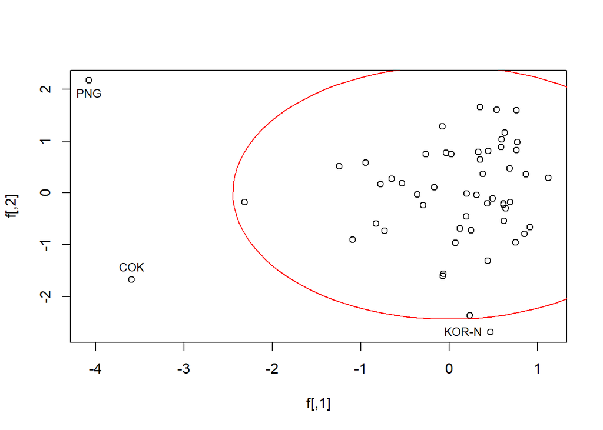

```r
s <- tcrossprod(L2)+Psi
f <- t(t(L2)%*%solve(s)%*%t(scale(x,scale=F)))
plot(f)
lines(ellipse::ellipse(cov(f),centre=colMeans(f)),col="red")
text(f[c(11,31,40),],labels=rownames(f)[c(11,31,40)],pos=c(3,2,1),cex=0.8)
```

Temos alguns outliers, como podem ser vistos acima. Faremos a mesma análise, agora com a matriz de correlações:

```r
R <- cor(x)
lambda <- eigen(R)$values
E <- eigen(R)$vectors
L <- E%*%diag(sqrt(lambda))
(L2 <- L[,1:2])
```

```
           [,1]       [,2]
[1,] -0.9103780 -0.3228503
[2,] -0.9234990 -0.3279673
[3,] -0.8869307 -0.3642220
[4,] -0.9513832  0.1278522
[5,] -0.9380805  0.2450762
[6,] -0.9063506  0.3355481
[7,] -0.8560043  0.3086096
```

```r
Psi <- diag(diag(S)-rowSums(L2**2))
```

A maratona não apresenta mais dominância sobre as outras corridas, o primeiro fator sendo um mais geral e o segundo sendo um leve contraste entre corridas mais extensas vs mais curtas.

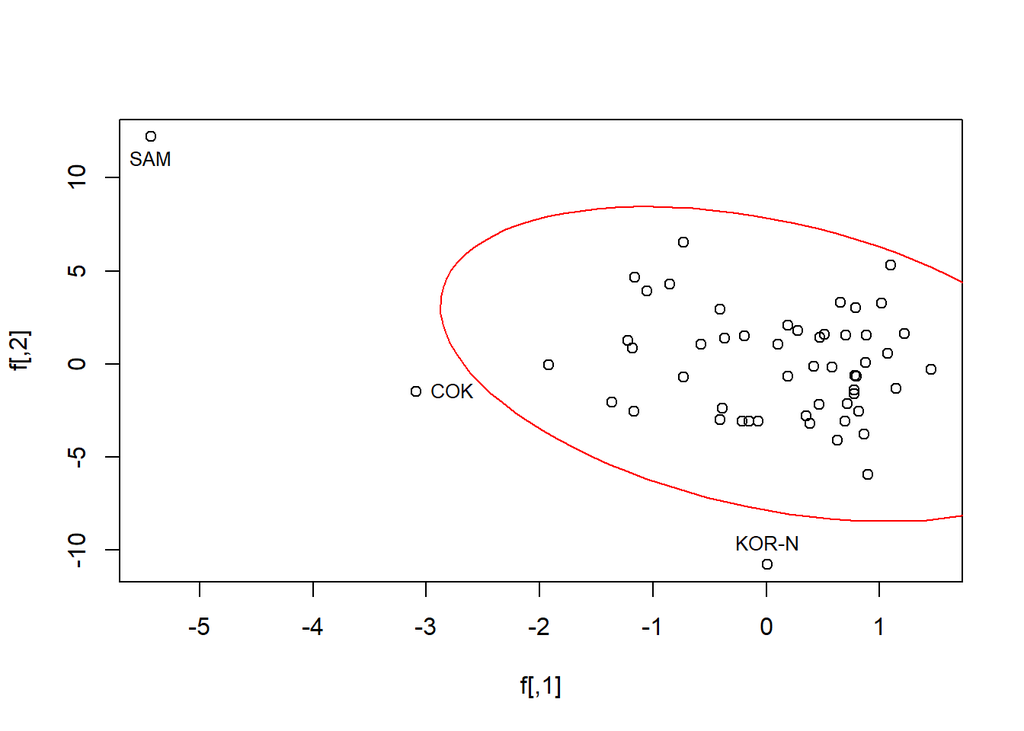

```r
r <- tcrossprod(L2)+Psi
z <- scale(x)
f <- t(t(L2)%*%solve(r)%*%t(z))
plot(f)
lines(ellipse::ellipse(cov(f),centre=colMeans(f)),col="red")
text(f[c(11,31,46),],labels=rownames(f)[c(11,31,46)],pos=c(4,3,1),cex=0.8)
```

Ainda há outliers, os mesmos mas com Samoa e não Papua-Nova Guiné. Ou seja, a diferença está na interpretabilidade dos fatores.

Agora converteremos os dados para velocidades para realizar novas análises:

```r
vel <- x
vel[,4:7] <- x[,4:7]*60
dist <- c(100,200,400,800,1500,3000,42195)
vel <- (1/vel)%*%diag(dist)
```

Assim, faremos primeiro para a matriz de covariâncias:

```r
S <- cov(vel)
lambda <- eigen(S)$values
E <- eigen(S)$vectors
L <- E%*%diag(sqrt(lambda))
(L2 <- L[,1:2])
```

```
           [,1]        [,2]
[1,] -0.2654622 -0.11030066
[2,] -0.3058070 -0.12725924
[3,] -0.3240683 -0.15218570
[4,] -0.2561324  0.01558890
[5,] -0.3347438  0.06185741
[6,] -0.3932516  0.11605334
[7,] -0.3617106  0.13043191
```

```r
Psi <- diag(diag(S)-rowSums(L2**2))
```

Após a conversão para velocidades, a maratona não está com a mesma predominância de antes. Inclusive, os fatores podem ser interpretados da mesma forma que na análise com a matriz de correlações dos dados originais. Verificamos por outliers:

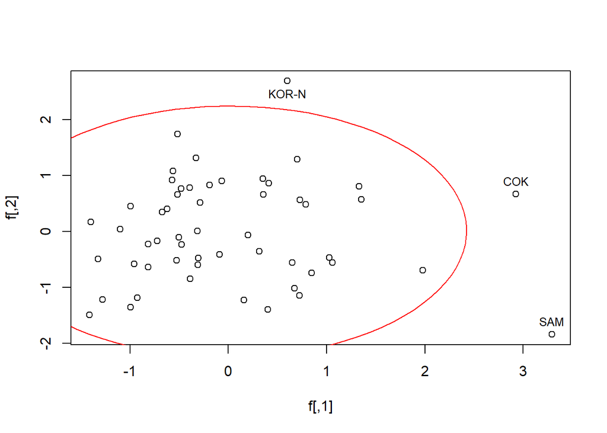

```r
s <- tcrossprod(L2)+Psi
f <- t(t(L2)%*%solve(s)%*%t(scale(vel,scale=F)))
plot(f)
lines(ellipse::ellipse(cov(f),centre=colMeans(f)),col="red")
text(f[c(11,31,46),],labels=rownames(f)[c(11,31,46)],pos=c(3,1,3),cex=0.8)
```

Os outliers são os mesmos que da análise com matriz de correlações dos dados originais. Faremos agora uma análise fatorial para a matriz de correlações dos dados de velocidades:

```r
R <- cor(vel)
lambda <- eigen(R)$values
E <- eigen(R)$vectors
L <- E%*%diag(sqrt(lambda))
(L2 <- L[,1:2])
```

```
           [,1]       [,2]
[1,] -0.9025800 -0.3419897
[2,] -0.9207713 -0.3354965
[3,] -0.8871700 -0.3524953
[4,] -0.9480517  0.1225758
[5,] -0.9430411  0.2267003
[6,] -0.9192476  0.3197371
[7,] -0.8657967  0.3538919
```

```r
Psi <- diag(diag(S)-rowSums(L2**2))
```

Os fatores possuem a mesma interpretação que antes. Verificamos outliers:

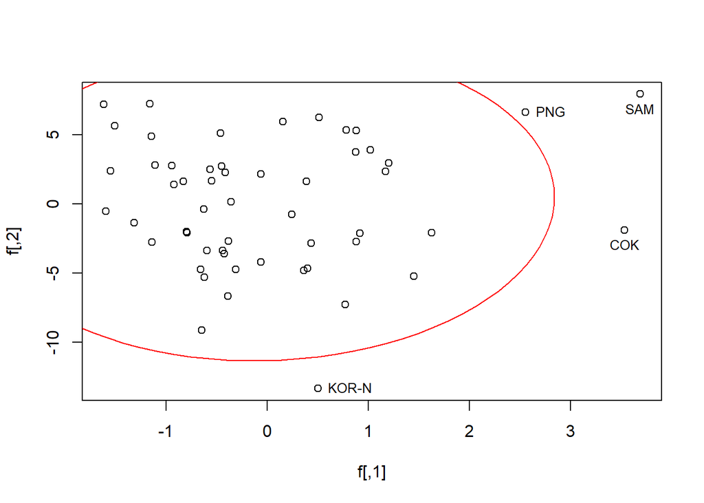

```r
r <- tcrossprod(L2)+Psi
z <- scale(vel)
f <- t(t(L2)%*%solve(r)%*%t(z))
plot(f)
lines(ellipse::ellipse(cov(f),centre=colMeans(f)),col="red")
text(f[c(11,31,40,46),],labels=rownames(f)[c(11,31,40,46)],pos=c(1,4,4,1),cex=0.8)
```

Aqui, os outliers são união de todos os conjuntos de outliers anteriores.

Entre todas as análises, a que mais prefiro é a para velocidades padronizadas (matriz R), por incluir todos os outliers da outras análises e reter as mesmas interpretações de fatores.

# Questão 8

Faremos uma análise fatorial usando a matriz de covariâncias amostral:

```r
x <- as.matrix(read.table("T8-6.DAT",row.names = 9,
                col.names=c("m100","m200","m400",
                            "m800","m1500","m5000","m10000","Mrtn","País")))
S <- cov(x)
lambda <- eigen(S)$values
E <- eigen(S)$vectors
L <- E%*%diag(sqrt(lambda))
(L2 <- L[,1:2])
```

```
           [,1]        [,2]
[1,] -0.1883693 -0.25041288
[2,] -0.3940314 -0.42659747
[3,] -1.0490420 -0.98394727
[4,] -0.0520359 -0.02754428
[5,] -0.1364199 -0.05307131
[6,] -0.7520248 -0.15446418
[7,] -1.7172313 -0.35519969
[8,] -9.2242423  0.21489669
```

```r
Psi <- diag(diag(S)-rowSums(L2**2))
```

Por conta da maratona ser muito mais extensa que as outras corridas, ela apresenta clara dominância sobre as variâncias. Além disso, ela também é extremamente predominante no primeiro fator, o que pode levar à interpretação como fator de resistência. O outro não é interpretável. Escores por regressão:

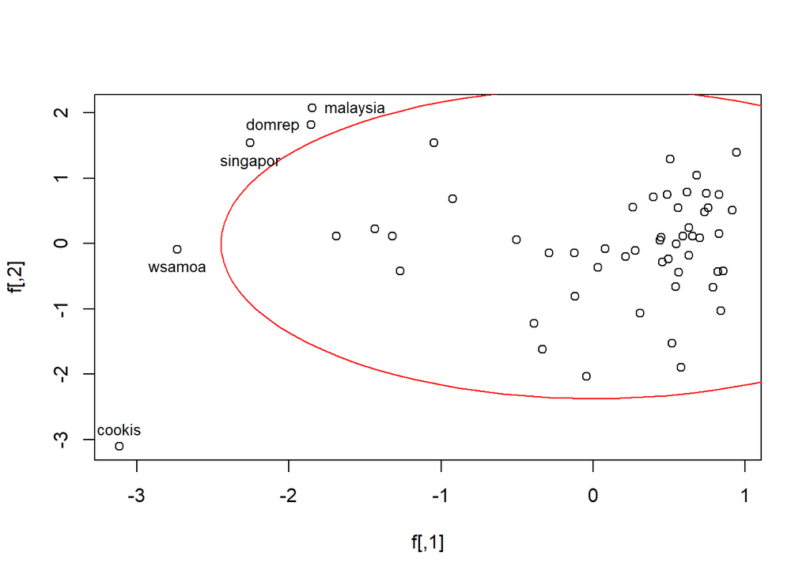

```r
s <- tcrossprod(L2)+Psi
f <- t(t(L2)%*%solve(s)%*%t(scale(x,scale=F)))
plot(f)
lines(ellipse::ellipse(cov(f),centre=colMeans(f)),col="red")
text(f[c(35,16,46,55,12),],
     labels=rownames(f)[c(35,16,46,55,12)],
     pos=c(4,2,1,1,3),cex=0.8)
```

Temos alguns outliers, como podem ser vistos acima. Faremos a mesma análise, agora com a matriz de correlações:

```r
R <- cor(x)
lambda <- eigen(R)$values
E <- eigen(R)$vectors
L <- E%*%diag(sqrt(lambda))
(L2 <- L[,1:2])
```

```
           [,1]        [,2]
[1,] -0.8171850  0.53105812
[2,] -0.8671665  0.43245706
[3,] -0.9152012  0.23258563
[4,] -0.9487545  0.01164452
[5,] -0.9593714 -0.13096330
[6,] -0.9376633 -0.29231413
[7,] -0.9438353 -0.28747025
[8,] -0.8798965 -0.41122586
```

```r
Psi <- diag(diag(S)-rowSums(L2**2))
```

A maratona não apresenta mais dominância sobre as outras corridas, o primeiro fator sendo um mais geral e o segundo sendo um contraste entre corridas mais extensas vs mais curtas.

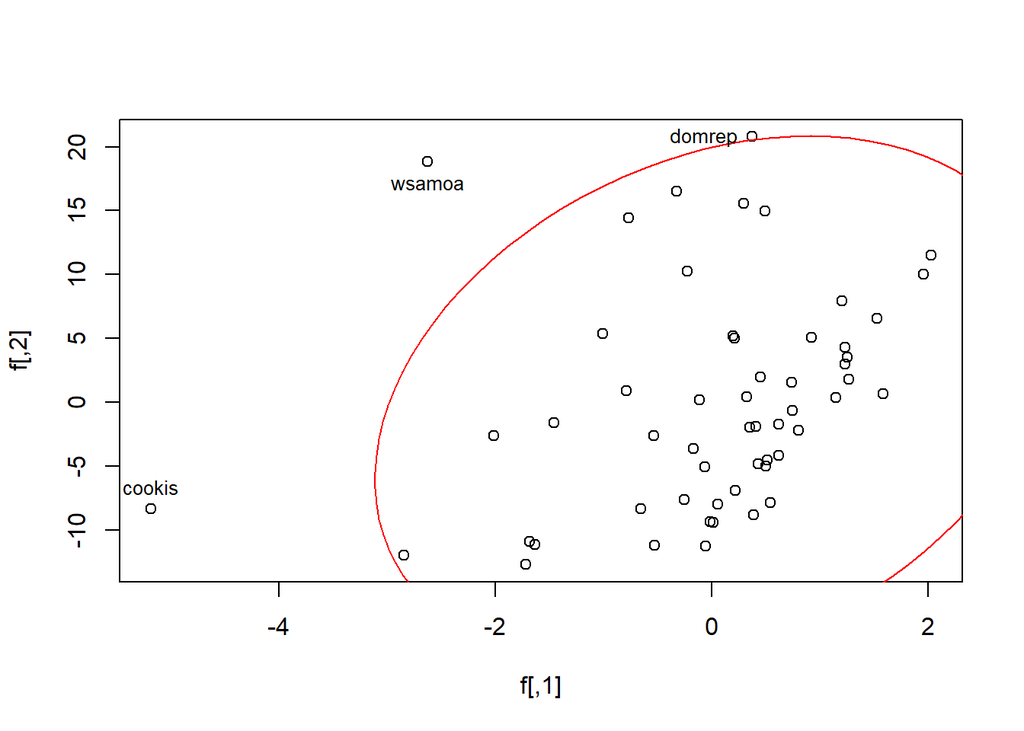

```r
r <- tcrossprod(L2)+Psi
z <- scale(x)
f <- t(t(L2)%*%solve(r)%*%t(z))
plot(f)
lines(ellipse::ellipse(cov(f),centre=colMeans(f)),col="red")
text(f[c(16,55,12),],
     labels=rownames(f)[c(16,55,12)],
     pos=c(2,1,3),cex=0.8)
```

Ainda há outliers, os mesmos mas sem Singapura e Malásia. Ou seja, a diferença está na interpretabilidade dos fatores.

Agora converteremos os dados para velocidades para realizar novas análises:

```r
vel <- x
vel[,-(1:3)] <- x[,-(1:3)]*60
dist <- c(100,200,400,800,1500,5000,10000,42195)
vel <- (1/vel)%*%diag(dist)
```

Assim, faremos primeiro para a matriz de covariâncias:

```r
S <- cov(vel)
lambda <- eigen(S)$values
E <- eigen(S)$vectors
L <- E%*%diag(sqrt(lambda))
(L2 <- L[,1:2])
```

```
           [,1]        [,2]
[1,] -0.2370338 -0.17404862
[2,] -0.2442729 -0.13573530
[3,] -0.2327346 -0.06664216
[4,] -0.2346799 -0.01616733
[5,] -0.2577723  0.02282214
[6,] -0.3055471  0.08534872
[7,] -0.3141991  0.08562152
[8,] -0.2860949  0.12182243
```

```r
Psi <- diag(diag(S)-rowSums(L2**2))
```

Após a conversão para velocidades, a maratona não está com a mesma predominância de antes. Inclusive, os fatores podem ser interpretados da mesma forma que na análise com a matriz de correlações dos dados originais. Verificamos por outliers:

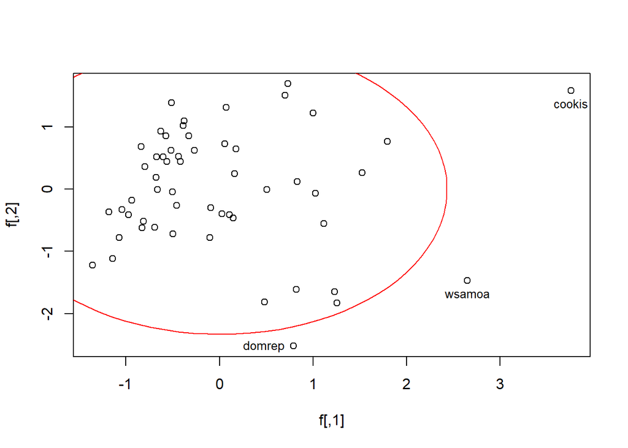

```r
s <- tcrossprod(L2)+Psi
f <- t(t(L2)%*%solve(s)%*%t(scale(vel,scale=F)))
plot(f)
lines(ellipse::ellipse(cov(f),centre=colMeans(f)),col="red")
text(f[c(16,55,12),],
     labels=rownames(f)[c(16,55,12)],
     pos=c(2,1,1),cex=0.8)
```

Os outliers são os mesmos que da análise com matriz de correlações dos dados originais. Faremos agora uma análise fatorial para a matriz de correlações dos dados de velocidades:

```r
R <- cor(vel)
lambda <- eigen(R)$values
E <- eigen(R)$vectors
L <- E%*%diag(sqrt(lambda))
(L2 <- L[,1:2])
```

```
           [,1]        [,2]
[1,] -0.8068877 -0.54561229
[2,] -0.8652017 -0.43764685
[3,] -0.9137267 -0.22687170
[4,] -0.9457370 -0.02366631
[5,] -0.9583882  0.12903797
[6,] -0.9331243  0.30232505
[7,] -0.9397642  0.29753945
[8,] -0.8767906  0.41422573
```

```r
Psi <- diag(diag(S)-rowSums(L2**2))
```

Os fatores possuem a mesma interpretação que antes. Verificamos outliers:

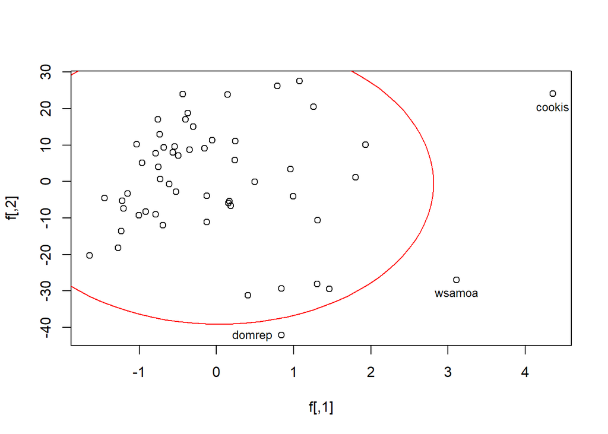

```r
r <- tcrossprod(L2)+Psi
z <- scale(vel)
f <- t(t(L2)%*%solve(r)%*%t(z))
plot(f)
lines(ellipse::ellipse(cov(f),centre=colMeans(f)),col="red")
text(f[c(16,55,12),],
     labels=rownames(f)[c(16,55,12)],
     pos=c(2,1,1),cex=0.8)
```

Aqui, os outliers são os mesmos que a análise anterior.

Assim, temos que tanto para dados de recordes masculinos quanto femininos, temos um fatores semelhantes em interpretação.